# Data Transformation and Viz

Ricardo Lastra

Marzo de 2023

## Agenda

- Getting Started with R Programming
- R_Basico_1.0
- R_Basico_1.1
- R_Basico_1.2
- R_dplyr
- R_ggplot
- Bonus

### Getting Started with R Programming

`OBJETIVO:` **Breve historia de R y contexto**

#### Historia de R

Ross Ihaka and Robert Gentleman desarrollaron `R` como un software *free* cuando impartían clases en la Universidad de Auckland en New Zealand a principios de 1990.

Lo crearon a partir del lenguaje estadístico denominado `S` y para diferenciar su trabajo usaron una sintaxis similar para su propio uso. En 1993 anunciaron su colaboración en las noticias del mailing list de `S`, muchas personas se interesaron y se sumaron a la colaboración. Dicha colaboración sigue en pie en el sitio https://www.r-project.org/

El lanzamiento oficial (1.0.0) fue en Febrero del 2000, para ese entonces ya era parte de la fundación de software libre GNU. Actualmente la última versión (3.6) está disponible desde Abril de este año para más de 30 países.

#### Ventajas y usos de R

Es un software que ayuda a la manipulación de datos, cálculos aritméticos y visualización de gráficos dinámicos.

El código es de fácil escritura y comprensión.

Excelente para el cálculo de matrices, vectores, algoritmos complejos.

Existe una colección muy amplia de herramientas para el análisis de datos, visualización y otros propósitos. `dplyr`, `data.table`, `tidyr` y `ggplot2` algunos de ellos.

Fácil desarrollo de herramientas con buen nivel de interacción como `blogdown` y `xaringan`.

#### Iniciando

Para descargar e instalar `R` en su última versión, deberán utilizar el siguiente link https://cran.r-project.org/bin/windows/base/ donde encontraran la versión para Windows que es el sistema operativo que todos tenemos.

Un lenguaje amigable, fácil de usar y entender, simple y efectivo.

Con `R` se distribuyen algunos paquetes, pero existen muchos más en el sitio CRAN, cubriendo así un amplio espectro de herramientas estadísticas, de cálculo y de visualización que les harán más divertida la vida.

En los próximos días les hare llegar documentos como estos, los cuales les serán de gran apoyo con cosas básicas, no podemos retener todo en la memoria, además de que cubriremos muchos comandos, ejemplos y funciones de las paqueterías.

[figure not shown]

Para las siguientes sesiones usaremos una interface muy “Fancy” denominada RStudio, la cual podrán descargar en el siguiente link https://www.rstudio.com/products/rstudio/download/ que los llevara a tener la versión más reciente.

Existen más programas o UI´s muy padres, Anaconda (luego revisan el siguiente link) https://www.anaconda.com/distribution/ tiene excelentes herramientas con Python y aun para R. También existe Visual Estudio, lo platicamos un poco en sesiones anteriores, recuerdan?, sin embargo una de las mejores herramientas con R es RStudio.

### R_Basico_1.0

`OBJETIVO:` **Vistazo de Rstudio y primeros comandos**

Recordando…

*R es un lenguaje computacional diseñado para la estadística.*

- Es gratis
- Amplias librerias
- Basto soporte, mailing list, blogs, tutoriales
- De facíl desarrollo
- Desarrolado por estadísticos

Recuerden que cualquier cosa que escriban en R muy probablemente no seran los primeros en intentarlo, hay una gran posibilidad que alguien ya haya escrito algun paquete justo para lo que necesitan.

Hecharemos un vistazo a la parte basica de RStudio que nos permitira entender el funcionamiento del lenguaje, sus alcances, sus aplicaciones y sus ventajas sobre las herramientas actuales que conocemos.

[figure not shown]

Inicien RStudio y abran un R script:

- En Windows click en el boton de Inicio y busquen Rstudio.
- Ya en Rstudio den click en `File -> New File -> R script`
- Guardenlo en su carpeta del curso `File -> Save As -> ruta a su carpeta y nombre del file`

Ahora traten de reproducir las siguientes notas.

Nota. Recuerden el simbolo `#` para comentar su codigo.

**FORMAS DE DECLARAR Ó GUARDAR Ó ALMACENAR Ó MANTENER VARIABLES:**

```r
x = 3
y <- 4
5 -> z
```

**Asi estan almacenadas en el ambiente:**

```r
x
```

```
## [1] 3
```

```r
y
```

```
## [1] 4
```

```r
z
```

```
## [1] 5
```

Nota. Los valores que guardamos pueden ser usados en subsecuentes operaciones, recuerden que lo mas limpio es poner el nombre a la izquierda y los valores a la derecha.

**SOBRESCRIBIR VARIABLES:**

```r
x = 4
y <- 5
6 -> z
```

**Asi estan almacenadas en el ambiente:**

```r
x
```

```
## [1] 4
```

```r
y
```

```
## [1] 5
```

```r
z
```

```
## [1] 6
```

**CALCULOS BASICOS:**

Operadores

```r
#SUMAS
25+25
```

```
## [1] 50
```

```r
x+y
```

```
## [1] 9
```

```r
#MULTIPLICACIONES
35*2
```

```
## [1] 70
```

```r
#DIVISIONES
x/y
```

```
## [1] 0.8
```

```r
#RESTAS
z-x-y
```

[output not shown]

```r
#Potencias
3^2
```

```
## [1] 9
```

```r
y^x
```

```
## [1] 625
```

**CALCULOS BASICOS**

FORMAS DE **NO** HACER CALCULOS BASICOS, ASI NO ES LA SINTAXIS DE R:

```r
#SUMAS
#=25+25

#MULTIPLICACIONES
#(35)(2)
```

**VECTORES**

```r
#Basicos
x <- c(1,4,3,1,3,2,2,2)
x[1]
```

```
## [1] 1
```

```r
x[2]
```

```
## [1] 4
```

```r
x[2:4]
```

```
## [1] 4 3 1
```

```r
x[-1]
```

```
## [1] 4 3 1 3 2 2 2
```

```r
x[-4]
```

```
## [1] 1 4 3 3 2 2 2
```

```r
x[x<=3]
```

```
## [1] 1 3 1 3 2 2 2
```

```r
#Función which (más adelante veremos, for, while, ifelse)
#Devuelve la posición del elemento que pidamos validar.
which(x==1)
```

```
## [1] 1 4
```

```r
#Quizá con el alfabeto es más claro.
which(letters == "g")
```

```
## [1] 7
```

```r
x==1
```

```
## [1]  TRUE FALSE FALSE  TRUE FALSE FALSE FALSE FALSE
```

```r
#Mas complejos con operaciones, guardamos vectores
Cebollas.huacal <- c(12,4,4,6,9,3)
Chiles.caja <- c(5,3,2,2,12,9)
#Multiplicamos vectores
Cebollas.precio <- Cebollas.huacal *200
Chiles.precio <- Chiles.caja *100
#Sumamos vectores
Cebollas.precio + Chiles.precio
```

```
## [1] 2900 1100 1000 1400 3000 1500
```

```r
#Tambien lo podemos hacer asi en 1 sola linea
Cebollas.huacal *200 + Chiles.caja *100
```

```
## [1] 2900 1100 1000 1400 3000 1500
```

**OBJETOS**

```r
objeto <- 3*3
```

**FUNCIONES**

```r
myfun = function(x, y){
  return (x*y)
}
myfun(3,4)
```

```
## [1] 12
```

```r
myfun2 = function(x, n=2){
  return(x^n)
}
myfun2(4)
```

```
## [1] 16
```

```r
myfun2(2, n=3)
```

```
## [1] 8
```

**R LOOP´S** (While - For)

Sintaxis *WHILE*:

while (test_expression){ statement }

```r
i <- 1
while (i < 6) {
  print(i)
  i = i+1
  }
```

```
## [1] 1
## [1] 2
## [1] 3
## [1] 4
## [1] 5
```

Sintaxis *FOR*:

for(var in seq){ expr }

```r
for (año in c(2014,2015,2016,2017,2018,2019)){
  print(paste("El año actual es", año))
}
```

```
## [1] "El año actual es 2014"
## [1] "El año actual es 2015"
## [1] "El año actual es 2016"
## [1] "El año actual es 2017"
## [1] "El año actual es 2018"
## [1] "El año actual es 2019"
```

Aún mejor…

```r
for (año in 2014:2019){
  print(paste("El año actual es", año))
}
```

```
## [1] "El año actual es 2014"
## [1] "El año actual es 2015"
## [1] "El año actual es 2016"
## [1] "El año actual es 2017"
## [1] "El año actual es 2018"
## [1] "El año actual es 2019"
```

lo ideal…

```r
años <- c(2014,2015,2016,2017,2018,2019)
for (i in años){
  print(paste("El año actual es", i))
}
```

```
## [1] "El año actual es 2014"
## [1] "El año actual es 2015"
## [1] "El año actual es 2016"
## [1] "El año actual es 2017"
## [1] "El año actual es 2018"
## [1] "El año actual es 2019"
```

**R FUNCTION´S** (Ifelse - Which)

Sintaxis *IFELSE*:

ifelse(test, yes, no)

```r
plazo <- c(6,9,12,24,30)
ifelse(plazo==9, "aplica" , "no aplica")
```

```
## [1] "no aplica" "aplica"    "no aplica" "no aplica" "no aplica"
```

más divertido…

```r
plazo <- c(6,9,12,24,30)
ifelse(plazo>=9 & plazo<=24, "aplica" , "no aplica")
```

```
## [1] "no aplica" "aplica"    "aplica"    "aplica"    "no aplica"
```

Sintaxis *WHICH*:

which(x, arr.ind = FALSE, useNames = TRUE)

```r
which(letters == "g")
```

```
## [1] 7
```

### R_Basico_1.1

`OBJETIVO:` **Como cargar datos, paquetes y librerias**

Cargando nuestros datos

R tiene algunas formas de leer archivos, los mas comunes son tablas, archivos planos, archivos con alguna codificacion especifica o estructurada. Aunque no sera el objetivo del curso, leer cadenas de texto, datos sin estructuras definidas o espcificas y archivos sin algun tipo de orden, es algo que tambien se puede hacer en R.

Para leer datos de un archivo, primero deben saber que tipo de archivo es, es decir, su extension. La tabla de abajo muestra una lista de funciones que pueden ser importadas segun el formato del archivo.

| tipo de datos | funcion | paquete |
| --- | --- | --- |
| comma separated (.csv) | `read_csv()` | readr |
| other delimited formats | `read_delim()` | readr |
| R (.Rds) | `read_rds()` | readr |
| Stata (.dta) | `read_dta()` | haven |
| SPSS (.sav) | `read_spss()` | haven |
| SAS (.sas7bdat) | `read_sas()` | haven |
| Excel (.xls, .xlsx) | `read_excel()` | readxl |
| regular delimited files | `fread()` | data.table |

Nota. Mas información ver documento de apoyo `data-import`

Paqueterias de R ó los famosos *packages*

Los paquetes de R pueden ser instalados desde el famoso CRAN, el cual es una red de archivos de alta gama. Para ello deberán usar la función `install.packages`. Cuando instalan un paquete ponen una copia en la computadora de forma local, pero aun no lo hace “usable”, solo esta “disponible”. Para usarlo deberan adjuntar o cargar la funcion de `library`.

Gracias a nuestro amigo Hadley y otros colaboradores, en este curso usaremos para prueba de carga el famoso “the tidyverse”. `Tidyverse` nos brinda grandes herramientas para manipulación basica y avanzada de datos, es muy funcional, facíl e intuitiva.

```r
install.packages("tidyverse")
```

```r
library(tidyverse)
```

Nota. Activar la ayuda en `R`:

Podemos usar la función `help` o el operador al inicio de cada sentencia `?`.

```r
#help(help)
#?str
```

Cargando nuestro primer archivo:

```r
#read_csv("path a un csv/EJEMPLO_CARGA.csv")
```

UPS!! Problemas!!!

Hagamos que este disponible la libreria…

```r
library(readr)
read_csv("data/Market_size.csv")
```

```
## -------------------------------------------------------- Delimiter: "," chr
## (12): ...1, ...2, ...3, ...4, ...5, ...6, ...7, ...8, ...9, ...10, ...11...
```

```
## # A tibble: 1,717 x 12
##    ...1        ...2  ...3  ...4  ...5  ...6  ...7  ...8  ...9  ...10 ...11 ...12
##    <chr>       <chr> <chr> <chr> <chr> <chr> <chr> <chr> <chr> <chr> <chr> <chr>
##  1 <NA>        <NA>  <NA>  <NA>  <NA>  <NA>  <NA>  <NA>  <NA>  <NA>  <NA>  <NA>
##  2 <NA>        <NA>  <NA>  <NA>  <NA>  <NA>  <NA>  <NA>  <NA>  <NA>  <NA>  <NA>
##  3 <NA>        <NA>  <NA>  <NA>  <NA>  <NA>  <NA>  <NA>  <NA>  <NA>  <NA>  <NA>
##  4 Market Siz~ <NA>  <NA>  <NA>  <NA>  <NA>  <NA>  <NA>  <NA>  <NA>  <NA>  <NA>
##  5 Geography   Cate~ Data~ Unit  Curr~ 2017  2018  2019  2020  2021  2022  2023
##  6 Azerbaijan  HW S~ Reta~ mill~ -     176.4 190.2 207.7 220.7 232.5 248.7 267.1
##  7 Azerbaijan  HW S~ Reta~ AZN ~ Curr~ 264.6 308.6 354.8 382.1 420.9 469.1 528.9
##  8 Azerbaijan  Soft~ Off-~ mill~ -     465.4 514.7 571.7 583.3 651.2 708.3 751.9
##  9 Azerbaijan  Soft~ Off-~ AZN ~ Curr~ 542.0 617.7 701.3 723.7 846.5 1,05~ 1,24~
## 10 Azerbaijan  Bott~ Off-~ mill~ -     187.3 194.3 203.6 219.4 234.4 252.1 265.5
## # i 1,707 more rows
```

¿Qué pasa aquí?, este tipo de issues es muy común, es necesario saltar algunos renglones hasta llegar al encabezado…

```r
library(readr)
read_csv("data/Market_size.csv", skip = 5)
```

```
## # A tibble: 1,712 x 12
##    Geography  Category `Data Type` Unit  `Current Constant` `2017` `2018` `2019`
##    <chr>      <chr>    <chr>       <chr> <chr>              <chr>  <chr>  <chr>
##  1 Azerbaijan HW Soft~ Retail Vol~ mill~ -                  176.4  190.2  207.7
##  2 Azerbaijan HW Soft~ Retail Val~ AZN ~ Current Prices     264.6  308.6  354.8
##  3 Azerbaijan Soft Dr~ Off-trade ~ mill~ -                  465.4  514.7  571.7
##  4 Azerbaijan Soft Dr~ Off-trade ~ AZN ~ Current Prices     542.0  617.7  701.3
##  5 Azerbaijan Bottled~ Off-trade ~ mill~ -                  187.3  194.3  203.6
##  6 Azerbaijan Bottled~ Off-trade ~ AZN ~ Current Prices     123.0  131.7  138.0
##  7 Azerbaijan Carbona~ Off-trade ~ mill~ -                  216.6  247.6  284.8
##  8 Azerbaijan Carbona~ Off-trade ~ AZN ~ Current Prices     234.2  270.8  313.6
##  9 Azerbaijan Regular~ Off-trade ~ mill~ -                  209.6  239.6  275.3
## 10 Azerbaijan Regular~ Off-trade ~ AZN ~ Current Prices     226.4  261.7  302.7
## # i 1,702 more rows
## # i 4 more variables: `2020` <chr>, `2021` <chr>, `2022` <chr>, `2023` <chr>
```

```r
market <- read_csv("data/Market_size.csv", skip = 5, n_max = 5)
market
```

```
## # A tibble: 5 x 12
##   Geography  Category  `Data Type` Unit  `Current Constant` `2017` `2018` `2019`
##   <chr>      <chr>     <chr>       <chr> <chr>               <dbl>  <dbl>  <dbl>
## 1 Azerbaijan HW Soft ~ Retail Vol~ mill~ -                    176.   190.   208.
## 2 Azerbaijan HW Soft ~ Retail Val~ AZN ~ Current Prices       265.   309.   355.
## 3 Azerbaijan Soft Dri~ Off-trade ~ mill~ -                    465.   515.   572.
## 4 Azerbaijan Soft Dri~ Off-trade ~ AZN ~ Current Prices       542    618.   701.
## 5 Azerbaijan Bottled ~ Off-trade ~ mill~ -                    187.   194.   204.
## # i 4 more variables: `2020` <dbl>, `2021` <dbl>, `2022` <dbl>, `2023` <dbl>
```

Solo leemos las primeras 5 filas/rows, revisen los atributos de la función `read_csv`.

Ahora lo mismo pero con otra libreria muy poderosa, de las preferidas de los estadisticos!!!

```r
#install.packages("data.table")
library(data.table)
market_ <- fread("data/Market_size.csv", skip = 5, sep = ",", header = T)
head(market_,5)
```

```
##     Geography                  Category           Data Type           Unit
## 1: Azerbaijan HW Soft Drinks - modelled       Retail Volume million litres
## 2: Azerbaijan HW Soft Drinks - modelled    Retail Value RSP    AZN million
## 3: Azerbaijan               Soft Drinks    Off-trade Volume million litres
## 4: Azerbaijan               Soft Drinks Off-trade Value RSP    AZN million
## 5: Azerbaijan             Bottled Water    Off-trade Volume million litres
##    Current Constant  2017  2018  2019  2020  2021    2022    2023
## 1:                - 176.4 190.2 207.7 220.7 232.5   248.7   267.1
## 2:   Current Prices 264.6 308.6 354.8 382.1 420.9   469.1   528.9
## 3:                - 465.4 514.7 571.7 583.3 651.2   708.3   751.9
## 4:   Current Prices 542.0 617.7 701.3 723.7 846.5 1,059.1 1,244.2
## 5:                - 187.3 194.3 203.6 219.4 234.4   252.1   265.5
```

Ahora validamos ó exploramos los datos que cargamos en el ambiente con las siguientes funciones estadísticas

```r
class(market_)
```

```
## [1] "data.table" "data.frame"
```

Podemos obtener aún más

```r
library(dplyr)
glimpse(market_)
```

```
## Rows: 1,712
## Columns: 12
## $ Geography          <chr> "Azerbaijan", "Azerbaijan", "Azerbaijan", "Azerbaij~
## $ Category           <chr> "HW Soft Drinks - modelled", "HW Soft Drinks - mode~
## $ `Data Type`        <chr> "Retail Volume", "Retail Value RSP", "Off-trade Vol~
## $ Unit               <chr> "million litres", "AZN million", "million litres", ~
## $ `Current Constant` <chr> "-", "Current Prices", "-", "Current Prices", "-", ~
## $ `2017`             <chr> "176.4", "264.6", "465.4", "542.0", "187.3", "123.0~
## $ `2018`             <chr> "190.2", "308.6", "514.7", "617.7", "194.3", "131.7~
## $ `2019`             <chr> "207.7", "354.8", "571.7", "701.3", "203.6", "138.0~
## $ `2020`             <chr> "220.7", "382.1", "583.3", "723.7", "219.4", "150.0~
## $ `2021`             <chr> "232.5", "420.9", "651.2", "846.5", "234.4", "167.0~
## $ `2022`             <chr> "248.7", "469.1", "708.3", "1,059.1", "252.1", "197~
## $ `2023`             <chr> "267.1", "528.9", "751.9", "1,244.2", "265.5", "224~
```

Un poco más

```r
str(market_)
```

```
## Classes 'data.table' and 'data.frame':   1712 obs. of  12 variables:
##  $ Geography       : chr  "Azerbaijan" "Azerbaijan" "Azerbaijan" "Azerbaijan" ...
##  $ Category        : chr  "HW Soft Drinks - modelled" "HW Soft Drinks - modelled" "Soft Drinks" "Soft Drinks" ...
##  $ Data Type       : chr  "Retail Volume" "Retail Value RSP" "Off-trade Volume" "Off-trade Value RSP" ...
##  $ Unit            : chr  "million litres" "AZN million" "million litres" "AZN million" ...
##  $ Current Constant: chr  "-" "Current Prices" "-" "Current Prices" ...
##  $ 2017            : chr  "176.4" "264.6" "465.4" "542.0" ...
##  $ 2018            : chr  "190.2" "308.6" "514.7" "617.7" ...
##  $ 2019            : chr  "207.7" "354.8" "571.7" "701.3" ...
##  $ 2020            : chr  "220.7" "382.1" "583.3" "723.7" ...
##  $ 2021            : chr  "232.5" "420.9" "651.2" "846.5" ...
##  $ 2022            : chr  "248.7" "469.1" "708.3" "1,059.1" ...
##  $ 2023            : chr  "267.1" "528.9" "751.9" "1,244.2" ...
##  - attr(*, ".internal.selfref")=<externalptr>
```

la mejor información!!!

```r
summary(market_)
```

```
##   Geography           Category          Data Type             Unit
##  Length:1712        Length:1712        Length:1712        Length:1712
##  Class :character   Class :character   Class :character   Class :character
##  Mode  :character   Mode  :character   Mode  :character   Mode  :character
##  Current Constant       2017               2018               2019
##  Length:1712        Length:1712        Length:1712        Length:1712
##  Class :character   Class :character   Class :character   Class :character
##  Mode  :character   Mode  :character   Mode  :character   Mode  :character
##      2020               2021               2022               2023
##  Length:1712        Length:1712        Length:1712        Length:1712
##  Class :character   Class :character   Class :character   Class :character
##  Mode  :character   Mode  :character   Mode  :character   Mode  :character
```

¿Llegaste hasta aquí? Felicidades, podemos avanzar y subir el volumen!!!

[figure not shown]

### R_Basico_1.2

`OBJETIVO:` **Manejo de datos**

Normalmente los datos en R son almacenados como `data.frame`

Un data.frame es una lista de vectores de la misma longitud, piensenlos como una tabla de observaciones (individuos), cada entrada del vector en la lista forma una columna, cada columna puede ser de diferente tipo, conocemos a las columnas como variables y a las filas como observaciones.

Un data.frame tiene entonces dos dimensiones correspondientes al numero de filas y columnas, en ese estricto orden.

Empezaremos a hacer nuestros primeros subsets, muy utiles en la vida real.

Empezamos con un clasico, `filter`

```r
filter(market_, Geography == "USA" & Category == "Energy Drinks")
```

```
##    Geography      Category           Data Type           Unit Current Constant
## 1:       USA Energy Drinks    Off-trade Volume million litres                -
## 2:       USA Energy Drinks Off-trade Value RSP    USD million   Current Prices
##        2017     2018     2019     2020     2021     2022     2023
## 1:  2,286.2  2,461.4  2,756.0  2,799.6  3,043.1  3,186.0  3,332.3
## 2: 11,945.3 12,951.4 14,595.7 14,729.2 16,043.5 18,020.8 19,425.0
```

Otra forma de filtrar con `in`… ¿encuentran parecido con algo?

```r
filter(market_, Geography == "USA", Category %in% c("Carbonates", "Concentrates"))
```

```
##    Geography     Category           Data Type           Unit Current Constant
## 1:       USA   Carbonates    Off-trade Volume million litres                -
## 2:       USA   Carbonates Off-trade Value RSP    USD million   Current Prices
## 3:       USA Concentrates    Off-trade Volume million litres                -
## 4:       USA Concentrates Off-trade Value RSP    USD million   Current Prices
##        2017     2018     2019     2020     2021     2022     2023
## 1: 33,083.6 32,980.0 32,642.7 33,017.1 32,881.7 32,013.6 31,664.5
## 2: 39,918.9 40,852.3 41,775.2 43,348.5 45,093.5 47,112.1 48,149.3
## 3:     15.6     16.1     16.2     18.0     18.3     18.4     18.8
## 4:  1,692.8  1,676.3  1,662.1  1,706.1  1,747.9  1,839.5  1,896.0
```

Buen acceso a ciertas observaciones, `slice`

```r
slice(market_, 1:5)
```

```
##     Geography                  Category           Data Type           Unit
## 1: Azerbaijan HW Soft Drinks - modelled       Retail Volume million litres
## 2: Azerbaijan HW Soft Drinks - modelled    Retail Value RSP    AZN million
## 3: Azerbaijan               Soft Drinks    Off-trade Volume million litres
## 4: Azerbaijan               Soft Drinks Off-trade Value RSP    AZN million
## 5: Azerbaijan             Bottled Water    Off-trade Volume million litres
##    Current Constant  2017  2018  2019  2020  2021    2022    2023
## 1:                - 176.4 190.2 207.7 220.7 232.5   248.7   267.1
## 2:   Current Prices 264.6 308.6 354.8 382.1 420.9   469.1   528.9
## 3:                - 465.4 514.7 571.7 583.3 651.2   708.3   751.9
## 4:   Current Prices 542.0 617.7 701.3 723.7 846.5 1,059.1 1,244.2
## 5:                - 187.3 194.3 203.6 219.4 234.4   252.1   265.5
```

¿Que pasó aqui?

```r
head(slice(market_,-c(1,2)))
```

```
##     Geography      Category           Data Type           Unit Current Constant
## 1: Azerbaijan   Soft Drinks    Off-trade Volume million litres                -
## 2: Azerbaijan   Soft Drinks Off-trade Value RSP    AZN million   Current Prices
## 3: Azerbaijan Bottled Water    Off-trade Volume million litres                -
## 4: Azerbaijan Bottled Water Off-trade Value RSP    AZN million   Current Prices
## 5: Azerbaijan    Carbonates    Off-trade Volume million litres                -
## 6: Azerbaijan    Carbonates Off-trade Value RSP    AZN million   Current Prices
##     2017  2018  2019  2020  2021    2022    2023
## 1: 465.4 514.7 571.7 583.3 651.2   708.3   751.9
## 2: 542.0 617.7 701.3 723.7 846.5 1,059.1 1,244.2
## 3: 187.3 194.3 203.6 219.4 234.4   252.1   265.5
## 4: 123.0 131.7 138.0 150.0 167.0   197.7   224.0
## 5: 216.6 247.6 284.8 278.4 316.9   342.1   359.5
## 6: 234.2 270.8 313.6 311.0 366.5   460.9   532.8
```

Revisemos con un `head` y un `tail`

```r
head(market_)
```

```
##     Geography                  Category           Data Type           Unit
## 1: Azerbaijan HW Soft Drinks - modelled       Retail Volume million litres
## 2: Azerbaijan HW Soft Drinks - modelled    Retail Value RSP    AZN million
## 3: Azerbaijan               Soft Drinks    Off-trade Volume million litres
## 4: Azerbaijan               Soft Drinks Off-trade Value RSP    AZN million
## 5: Azerbaijan             Bottled Water    Off-trade Volume million litres
## 6: Azerbaijan             Bottled Water Off-trade Value RSP    AZN million
##    Current Constant  2017  2018  2019  2020  2021    2022    2023
## 1:                - 176.4 190.2 207.7 220.7 232.5   248.7   267.1
## 2:   Current Prices 264.6 308.6 354.8 382.1 420.9   469.1   528.9
## 3:                - 465.4 514.7 571.7 583.3 651.2   708.3   751.9
## 4:   Current Prices 542.0 617.7 701.3 723.7 846.5 1,059.1 1,244.2
## 5:                - 187.3 194.3 203.6 219.4 234.4   252.1   265.5
## 6:   Current Prices 123.0 131.7 138.0 150.0 167.0   197.7   224.0
```

```r
tail(market_)
```

```
##         Geography                Category           Data Type           Unit
## 1: United Kingdom           Energy Drinks    Off-trade Volume million litres
## 2: United Kingdom           Energy Drinks Off-trade Value RSP    GBP million
## 3: United Kingdom           Sports Drinks    Off-trade Volume million litres
## 4: United Kingdom           Sports Drinks Off-trade Value RSP    GBP million
## 5: United Kingdom Asian Speciality Drinks    Off-trade Volume million litres
## 6: United Kingdom Asian Speciality Drinks Off-trade Value RSP    GBP million
##    Current Constant    2017    2018    2019    2020    2021    2022    2023
## 1:                -   543.2   554.6   570.9   589.3   639.1   684.9   711.2
## 2:   Current Prices 1,290.6 1,297.0 1,353.7 1,405.0 1,591.9 1,848.7 2,002.4
## 3:                -   127.9   128.1   137.8   122.3   140.2   152.6   159.6
## 4:   Current Prices   186.8   189.6   198.3   177.8   210.3   244.2   261.4
## 5:                -     6.1     6.3     6.6     6.5     6.4     6.5     6.7
## 6:   Current Prices    21.3    22.6    24.1    24.4    24.8    27.1    29.3
```

Entonces `slice` y `filter` se usan para extraer algun tipo de “observación, row, fila, value, entrada, etc.”, de la misma forma usamos `select` para acceder a las columnas.

```r
select(slice(market_, 1583:1609), c("2021", "2022", "2023"))
```

```
##         2021     2022     2023
##  1:  8,598.7  8,724.8  8,870.0
##  2:  4,443.2  4,663.3  4,874.4
##  3: 10,391.6 10,398.1 10,373.5
##  4:  6,298.9  6,923.5  7,198.5
##  5:  6,915.0  6,931.4  6,923.4
##  6:  2,333.6  2,546.0  2,640.7
##  7:  2,211.0  2,189.1  2,152.0
##  8:  2,020.9  2,205.4  2,262.0
##  9:  1,419.6  1,371.6  1,316.3
## 10:  1,304.4  1,401.4  1,410.9
## 11:    791.4    817.5    835.6
## 12:    716.5    804.0    851.1
## 13:      3.0      3.0      3.0
## 14:     25.4     27.5     28.5
## 15:    653.4    637.2    622.7
## 16:    821.9    878.3    888.9
## 17:     28.5     31.4     34.6
## 18:    125.9    151.1    171.0
## 19:    185.2    193.3    206.2
## 20:    221.9    254.2    279.3
## 21:     90.9     96.8    101.7
## 22:    284.1    335.4    362.4
## 23:    304.6    315.8    330.0
## 24:    465.4    525.6    565.8
## 25:        -        -        -
## 26:        -        -        -
## 27:    700.8    726.0    748.9
##         2021     2022     2023
```

¿Que pasó aqui?, expliquenme chic@s list@s!!!

…podemos usar algo super util como el simbolo de `$`, el cual nos ayudara a acceder a una columna especifica de un df, ojo, primero cambiamos el tipo de dato, después podemos ejecutar cualquier calculo removiendo los NA que se introducen por default.

```r
market_$"2017" <- as.numeric(market_$"2017")
sd(market_$"2017",na.rm=T)
```

```
## [1] 244.2039
```

o tambien…

```r
mean(market_$"2017",na.rm=T)
```

```
## [1] 209.6767
```

### R_dplyr

`OBJETIVO:` **Pipes, datos en forma tidy y verbos de la librería**

Sigan cuidadosamente las siguientes instrucciones, inicien RStudio y generen un nuevo proyecto:

- En Windows click en el botón de Inicio y busquen Rstudio.
- Ya en Rstudio den click en `File -> New Project... -> Existing Directory -> Browse... -> seleccionar carpeta destino -> Open -> Create Project`
- Ya que se abre otra pantalla de R, dar click en `File -> New File -> R script`
- Guárdenlo en su carpeta del Proyecto nuevo que acabamos de crear. `File -> Save As -> ruta a su carpeta y nombre del file`
- Instalen `dplyr`(en caso de no tenerlo aún)
- Iniciemos con lo siguiente:

Debemos cargar el archivo *Pack_type* con varias pestañas, contribucion de nuestro amigo LEE.

De la siguiente forma cargamos 1 sola pestaña, pero no es la escencia de esto.

```r
library(dplyr)
library(readxl)
pestaña <- read_excel("data/Pack_type.xls", sheet = 1)
head(pestaña)
```

Revisamos de la siguiente manera las pestañas y seleccionamos la que queremos revisar.

```r
#recuerden que el path de cada equipo es diferente
ruta <- "data/Pack_type.xls"
excel_sheets(path = ruta)
```

```
## [1] "Statistics Data" "Hoja1"           "Hoja2"
```

Ojo. Muestra inclusive las pestañas que esten ocultas.

Cargamos el archivo y la pestaña deseada:

```r
pack_type <- read_excel(path = ruta, sheet = "Statistics Data", skip = 5)
head(pack_type)
```

```
## # A tibble: 6 x 13
##   Geography Category      `Packaging Class` `Pack Type` `Data Type` Unit  `2017`
##   <chr>     <chr>         <chr>             <chr>       <chr>       <chr> <chr>
## 1 Argentina Soft Drinks ~ Total             Total Pack~ Retail/off~ mill~ 10689~
## 2 Austria   Soft Drinks ~ Total             Total Pack~ Retail/off~ mill~ 1874.~
## 3 Australia Soft Drinks ~ Total             Total Pack~ Retail/off~ mill~ 6078.5
## 4 Belgium   Soft Drinks ~ Total             Total Pack~ Retail/off~ mill~ 3476.~
## 5 Brazil    Soft Drinks ~ Total             Total Pack~ Retail/off~ mill~ 29303~
## 6 Canada    Soft Drinks ~ Total             Total Pack~ Retail/off~ mill~ 11911~
## # i 6 more variables: `2018` <chr>, `2019` <chr>, `2020` <chr>, `2021` <chr>,
## #   `2022` <chr>, `2023` <chr>
```

Revisamos los datos:

```r
summary(pack_type)
```

```
##   Geography           Category         Packaging Class     Pack Type
##  Length:843         Length:843         Length:843         Length:843
##  Class :character   Class :character   Class :character   Class :character
##  Mode  :character   Mode  :character   Mode  :character   Mode  :character
##   Data Type             Unit               2017               2018
##  Length:843         Length:843         Length:843         Length:843
##  Class :character   Class :character   Class :character   Class :character
##  Mode  :character   Mode  :character   Mode  :character   Mode  :character
##      2019               2020               2021               2022
##  Length:843         Length:843         Length:843         Length:843
##  Class :character   Class :character   Class :character   Class :character
##  Mode  :character   Mode  :character   Mode  :character   Mode  :character
##      2023
##  Length:843
##  Class :character
##  Mode  :character
```

Repaso.

`Dplyr` Es una libreria de R para manejo, transformación y control de datos. COnsiste en una serie de funciones que nos permiten de forma sencilla y simplificada escribir pipelines de datos (en el mundo de `SQL` mejor conocidos como `querys`).

Estas transformaciones son mejor conocidas como `Data manipulation` ó `Data wrangling`. Esta forma de manipular datos combina naturalmente verbos en inglés que hacen referencia a la funcionalidad que se trata de emplear directo al dato.

El amplio workspace que `R`maneja a traves de su extensa comunidad permite que `Dplyr` pueda ser desarrollado con amplio y basto numero de referencias para el desarrollo de codigo para manipulación de datos.

Adicionalmente `Dplyr` cuenta con interacciones con otras librerias, lenguajes y plataformas de uso y manipulación de datos. Es posible traducir con la libreria `dbplyr` pipes de `Dplyr` hacia “queries” de `SQL`; o también con la libreria `dtplyr` manejar volumenes grandes de datos en “memoria”, esto a traves de la traducción de pipes a codigo eficiente de `data.table`.

**Verbos de `dplyr` que usaremos:**

- mutate() adds new variables that are functions of existing variables
- select() picks variables based on their names.
- filter() picks cases based on their values.
- summarise() reduces multiple values down to a single summary.
- arrange() changes the ordering of the rows.

Provided by https://dplyr.tidyverse.org/

(Nota, en ese link hay un cheat sheet muy bueno de “Data transformation”)

#### **Atención!!!… usaremos un simbolo muy curioso para manipulación de datos con Dplyr, mejor conocido como *operator* (%>%)**

¿Están listos chic@s?

[figure not shown]

Iniciamos con el verbo `mutate()`, el cual nos genera una nuevas variables a partir de otra dada que cumpla cierta condición. En este ejemplo modificamos las variables que son `char` a `numéricas`:

```r
pack_type_moded <- pack_type %>%
  mutate(across(7:13, as.numeric))
```

Revisamos como quedo el nuevo dataset.

```r
head(pack_type_moded)
```

```
## # A tibble: 6 x 13
##   Geography Category      `Packaging Class` `Pack Type` `Data Type` Unit  `2017`
##   <chr>     <chr>         <chr>             <chr>       <chr>       <chr>  <dbl>
## 1 Argentina Soft Drinks ~ Total             Total Pack~ Retail/off~ mill~ 10690.
## 2 Austria   Soft Drinks ~ Total             Total Pack~ Retail/off~ mill~  1874.
## 3 Australia Soft Drinks ~ Total             Total Pack~ Retail/off~ mill~  6078.
## 4 Belgium   Soft Drinks ~ Total             Total Pack~ Retail/off~ mill~  3477.
## 5 Brazil    Soft Drinks ~ Total             Total Pack~ Retail/off~ mill~ 29303.
## 6 Canada    Soft Drinks ~ Total             Total Pack~ Retail/off~ mill~ 11911.
## # i 6 more variables: `2018` <dbl>, `2019` <dbl>, `2020` <dbl>, `2021` <dbl>,
## #   `2022` <dbl>, `2023` <dbl>
```

Aquí otro ejemplo muy util para generar variables calculadas de la diferencia del crecimiento/decremento del 2023 vs 2022:

```r
pack_type %>%
  mutate(across(7:13, as.numeric)) %>%
  mutate(Year_diff= ((`2023` / `2022`)-1)*100)
```

```
## # A tibble: 843 x 14
##    Geography   Category   `Packaging Class` `Pack Type` `Data Type` Unit  `2017`
##    <chr>       <chr>      <chr>             <chr>       <chr>       <chr>  <dbl>
##  1 Argentina   Soft Drin~ Total             Total Pack~ Retail/off~ mill~ 1.07e4
##  2 Austria     Soft Drin~ Total             Total Pack~ Retail/off~ mill~ 1.87e3
##  3 Australia   Soft Drin~ Total             Total Pack~ Retail/off~ mill~ 6.08e3
##  4 Belgium     Soft Drin~ Total             Total Pack~ Retail/off~ mill~ 3.48e3
##  5 Brazil      Soft Drin~ Total             Total Pack~ Retail/off~ mill~ 2.93e4
##  6 Canada      Soft Drin~ Total             Total Pack~ Retail/off~ mill~ 1.19e4
##  7 Switzerland Soft Drin~ Total             Total Pack~ Retail/off~ mill~ 2.08e3
##  8 Chile       Soft Drin~ Total             Total Pack~ Retail/off~ mill~ 4.62e3
##  9 China       Soft Drin~ Total             Total Pack~ Retail/off~ mill~ 1.36e5
## 10 Colombia    Soft Drin~ Total             Total Pack~ Retail/off~ mill~ 9.04e3
## # i 833 more rows
## # i 7 more variables: `2018` <dbl>, `2019` <dbl>, `2020` <dbl>, `2021` <dbl>,
## #   `2022` <dbl>, `2023` <dbl>, Year_diff <dbl>
```

Mejorando:

```r
pack_type %>%
  mutate(across(7:13, as.numeric)) %>%
  mutate(Year_diff= paste0(round(((`2023` / `2022`)-1)*100,2),"%"))
```

```
## # A tibble: 843 x 14
##    Geography   Category   `Packaging Class` `Pack Type` `Data Type` Unit  `2017`
##    <chr>       <chr>      <chr>             <chr>       <chr>       <chr>  <dbl>
##  1 Argentina   Soft Drin~ Total             Total Pack~ Retail/off~ mill~ 1.07e4
##  2 Austria     Soft Drin~ Total             Total Pack~ Retail/off~ mill~ 1.87e3
##  3 Australia   Soft Drin~ Total             Total Pack~ Retail/off~ mill~ 6.08e3
##  4 Belgium     Soft Drin~ Total             Total Pack~ Retail/off~ mill~ 3.48e3
##  5 Brazil      Soft Drin~ Total             Total Pack~ Retail/off~ mill~ 2.93e4
##  6 Canada      Soft Drin~ Total             Total Pack~ Retail/off~ mill~ 1.19e4
##  7 Switzerland Soft Drin~ Total             Total Pack~ Retail/off~ mill~ 2.08e3
##  8 Chile       Soft Drin~ Total             Total Pack~ Retail/off~ mill~ 4.62e3
##  9 China       Soft Drin~ Total             Total Pack~ Retail/off~ mill~ 1.36e5
## 10 Colombia    Soft Drin~ Total             Total Pack~ Retail/off~ mill~ 9.04e3
## # i 833 more rows
## # i 7 more variables: `2018` <dbl>, `2019` <dbl>, `2020` <dbl>, `2021` <dbl>,
## #   `2022` <dbl>, `2023` <dbl>, Year_diff <chr>
```

Ahora revisamos que hace el verbo `select()`.

¿Encuentras algun parecido a cursos anteriores?

```r
pack_type %>%
  select(c("Geography","Category","2022","2023")) %>%
  mutate(across(3:4, as.numeric)) %>% #ojo aquí, los indices cambian al recortar el no. de columnas
  mutate(Year_diff= paste0(round(((`2023` / `2022`)-1)*100,2),"%"))
```

```
## # A tibble: 843 x 5
##    Geography   Category               `2022`  `2023` Year_diff
##    <chr>       <chr>                   <dbl>   <dbl> <chr>
##  1 Argentina   Soft Drinks Packaging  10356.  10700. 3.33%
##  2 Austria     Soft Drinks Packaging   2088.   2065. -1.09%
##  3 Australia   Soft Drinks Packaging   6698.   6803. 1.57%
##  4 Belgium     Soft Drinks Packaging   3692.   3704  0.34%
##  5 Brazil      Soft Drinks Packaging  32387.  33591. 3.72%
##  6 Canada      Soft Drinks Packaging  12471.  12638. 1.34%
##  7 Switzerland Soft Drinks Packaging   2186.   2202. 0.7%
##  8 Chile       Soft Drinks Packaging   6127.   6444. 5.16%
##  9 China       Soft Drinks Packaging 158475. 166178. 4.86%
## 10 Colombia    Soft Drinks Packaging  11577.  11753. 1.52%
## # i 833 more rows
```

Podemos obtener el nombre de nuestras columnas para identificarlas mas facilmente…

```r
colnames(pack_type_moded)
```

```
##  [1] "Geography"       "Category"        "Packaging Class" "Pack Type"
##  [5] "Data Type"       "Unit"            "2017"            "2018"
##  [9] "2019"            "2020"            "2021"            "2022"
## [13] "2023"
```

No guardamos lo siguiente en la variable, solo observen que pasa.

```r
pack_type %>%
  select(ends_with("Type")) %>%
  head()
```

```
## # A tibble: 6 x 2
##   `Pack Type`     `Data Type`
##   <chr>           <chr>
## 1 Total Packaging Retail/off-trade Unit Volume
## 2 Total Packaging Retail/off-trade Unit Volume
## 3 Total Packaging Retail/off-trade Unit Volume
## 4 Total Packaging Retail/off-trade Unit Volume
## 5 Total Packaging Retail/off-trade Unit Volume
## 6 Total Packaging Retail/off-trade Unit Volume
```

Y el verbo `filter()` similar al que ya habiamos visto, ojo, esto es **Dplyr**!!.

```r
pack_type %>%
  filter(Geography  == "Mexico", `Pack Type` %in% c("Glass","Glass Bottles","Glass Jars"))
```

```
## # A tibble: 2 x 13
##   Geography Category      `Packaging Class` `Pack Type` `Data Type` Unit  `2017`
##   <chr>     <chr>         <chr>             <chr>       <chr>       <chr> <chr>
## 1 Mexico    Soft Drinks ~ Total             Glass       Retail/off~ mill~ 4816.~
## 2 Mexico    Soft Drinks ~ Total             Glass Bott~ Retail/off~ mill~ 4816.~
## # i 6 more variables: `2018` <chr>, `2019` <chr>, `2020` <chr>, `2021` <chr>,
## #   `2022` <chr>, `2023` <chr>
```

El siguiente verbo `summarise()` es de gran utilidad, lo usaremos mucho, esperen a que lleguemos al mundo visual de `ggplot`.

Tenemos la variable **dist_pais** que tiene la extracción del numero de registros por pais, la usamos.

```r
dist_pais <- pack_type %>%
  group_by(Geography) %>%
  summarise(cuenta = n())
```

```r
dist_pais
```

```
## # A tibble: 43 x 2
##    Geography cuenta
##    <chr>      <int>
##  1 Argentina     17
##  2 Australia     20
##  3 Austria       18
##  4 Belgium       18
##  5 Brazil        21
##  6 Canada        23
##  7 Chile         16
##  8 China         20
##  9 Colombia      21
## 10 Denmark       16
## # i 33 more rows
```

Y por ultimo un verbo para ordenar o acomodar nuestros valores muy usado es `arrange()`

Acomodamos por forma “descendente”…

[output not shown]

Y luego “ascendente”…

```r
dist_pais %>%
  arrange(cuenta)
```

```
## # A tibble: 43 x 2
##    Geography        cuenta
##    <chr>             <int>
##  1 Israel               11
##  2 Finland              14
##  3 Hong Kong, China     14
##  4 Vietnam              15
##  5 Chile                16
##  6 Denmark              16
##  7 New Zealand          16
##  8 Philippines          16
##  9 Portugal             16
## 10 Argentina            17
## # i 33 more rows
```

Comando extra y util. Quitamos espacios feos de los nombres de columnas:

```r
names(pack_type) <- gsub(" ", "_", names(pack_type))
colnames(pack_type)
```

```
##  [1] "Geography"       "Category"        "Packaging_Class" "Pack_Type"
##  [5] "Data_Type"       "Unit"            "2017"            "2018"
##  [9] "2019"            "2020"            "2021"            "2022"
## [13] "2023"
```

**…y la magia de `dplyr` es: un solo PIPE!!!!!**

```r
pack_type %>%
  mutate(across(7:13, as.numeric)) %>%
  mutate(Year_diff= paste0(round(((`2023` / `2022`)-1)*100,2),"%")) %>%
  select(c("Geography","Pack_Type","2022","2023", "Year_diff")) %>%
  filter(Geography  == "Mexico") %>%
  group_by(Pack_Type) %>%
  summarise(Diff = `2023` - `2022`,
            Year_diff)
```

```
## # A tibble: 22 x 3
##    Pack_Type                     Diff Year_diff
##    <chr>                        <dbl> <chr>
##  1 Brick Liquid Cartons        79.9   7.35%
##  2 Composite Containers         0     0%
##  3 Flexible Aluminium/Paper    40.7   1.81%
##  4 Flexible Aluminium/Plastic  -0.100 -2.17%
##  5 Flexible Packaging         -60     -2.49%
##  6 Flexible Plastic            -1     -2.15%
##  7 Folding Cartons             -0.5   -1.43%
##  8 Gable Top Liquid Cartons    10.9   2.09%
##  9 Glass                      206.    3.73%
## 10 Glass Bottles              206.    3.73%
## # i 12 more rows
```

Dejamos todas los paises, lo guardan en su variable y listo!!!

```r
crecimiento_tipo_empaque <- pack_type %>%
  mutate(across(7:13, as.numeric)) %>%
  mutate(Year_diff= paste0(round(((`2023` / `2022`)-1)*100,2),"%")) %>%
  select(c("Geography","Pack_Type","2022","2023", "Year_diff")) %>%
  group_by(Pack_Type) %>%
  summarise(Diff = `2023` - `2022`,
            Year_diff) %>%
  na.omit() %>%
  arrange(Year_diff)
crecimiento_tipo_empaque
```

```
## # A tibble: 830 x 3
## # Groups:   Pack_Type [34]
##    Pack_Type                     Diff Year_diff
##    <chr>                        <dbl> <chr>
##  1 PET Bottles                 -2.40  -0.03%
##  2 Metal Bottles               -0.100 -0.1%
##  3 Metal Beverage Cans        -75.3   -0.13%
##  4 Brick Liquid Cartons        -0.700 -0.14%
##  5 Metal                      -81     -0.14%
##  6 Shaped Liquid Cartons       -0.400 -0.16%
##  7 Brick Liquid Cartons        -1.90  -0.18%
##  8 Flexible Aluminium/Plastic  -0.100 -0.31%
##  9 Liquid Cartons              -3.5   -0.37%
## 10 Flexible Packaging          -0.400 -0.42%
## # i 820 more rows
```

Aplausos!!!

### R_ggplot

`OBJETIVO:` **Graficar entendiendo los datos, escalas y tipos de gráficos, mejorar visualizaciones actuales**

Para esta sección de visualización, pueden buscar referencias como [esta](https://infogram.com/es/pagina/visualizacion-datos), que nos brindan un contexto apropiado de lo que representan los datos.

```r
#Quitamos las comas y redondeamos la cifra, ademas que guardamos la variable como entero
library(readr)
market <- pack_type %>%
  mutate(`2022` = parse_number(`2022`))
#parse_number esta dentro de readr
```

revisamos de nuevo:

```r
str(market)
```

```
## tibble [843 x 13] (S3: tbl_df/tbl/data.frame)
##  $ Geography      : chr [1:843] "Argentina" "Austria" "Australia" "Belgium" ...
##  $ Category       : chr [1:843] "Soft Drinks Packaging" "Soft Drinks Packaging" "Soft Drinks Packaging" "Soft Drinks Packaging" ...
##  $ Packaging_Class: chr [1:843] "Total" "Total" "Total" "Total" ...
##  $ Pack_Type      : chr [1:843] "Total Packaging" "Total Packaging" "Total Packaging" "Total Packaging" ...
##  $ Data_Type      : chr [1:843] "Retail/off-trade Unit Volume" "Retail/off-trade Unit Volume" "Retail/off-trade Unit Volume" "Retail/off-trade Unit Volume" ...
##  $ Unit           : chr [1:843] "million units" "million units" "million units" "million units" ...
##  $ 2017           : chr [1:843] "10689.6" "1874.0999999999999" "6078.5" "3476.6999999999998" ...
##  $ 2018           : chr [1:843] "10428.700000000001" "1929.5999999999999" "6226.6999999999998" "3564.0999999999999" ...
##  $ 2019           : chr [1:843] "9461.3999999999996" "1984.0999999999999" "6310.1000000000004" "3505.8000000000002" ...
##  $ 2020           : chr [1:843] "9792.2000000000007" "2072" "6405.6999999999998" "3725" ...
##  $ 2021           : chr [1:843] "9944.7999999999993" "2145.1999999999998" "6580.3000000000002" "3678" ...
##  $ 2022           : num [1:843] 10356 2088 6698 3692 32387 ...
##   ..- attr(*, "problems")= tibble [13 x 4] (S3: tbl_df/tbl/data.frame)
##   .. ..$ row     : int [1:13] 88 128 208 212 312 313 565 573 581 585 ...
##   .. ..$ col     : int [1:13] NA NA NA NA NA NA NA NA NA NA ...
##   .. ..$ expected: chr [1:13] "a number" "a number" "a number" "a number" ...
##   .. ..$ actual  : chr [1:13] "-" "-" "-" "-" ...
##  $ 2023           : chr [1:843] "10700.4" "2064.9000000000001" "6803.1000000000004" "3704" ...
```

Ahora si pudieron cargar `tidyverse` solo habiliten la libreria.

```r
library(ggplot2)
```

Si *NO* pudieron cargar `tidyverse`, descarguen `ggplot2` y habiliten la libreria.

```r
#install.packages("ggplot2")
library(ggplot2)
```

Ventajas de `ggplot2`:

- Muy flexible
- Fácil de interpretar, sintaxis sencilla
- Sistema ya muy avanzado para graficar
- Ecosistema amplio
- Comunidad amplia, gran soporte
- Basado en el libro “The Grammar of Graphics”

¿Cómo se usa?

Empezamos con la función ggplot(), integrando nuestra base y sus variables (con aes()). Luego agregamos las coordenadas o puntos a graficar con geom_point() o con geom_histogram(), luego las escalas ó colores (como puede ser scale_colour_brewer()), algunas especificaciones como facet_wrap() y hasta títulos o marcas.

¿Y si graficamos con R base? `ggplot2` VS R base de una manera muy sencilla.

[figure not shown]

```r
hist(market$`2023`)
```

Y con `ggplot2` se ve lo mismo de la siguiente forma:

[figure not shown]

```r
ggplot(market, aes(x = `2023`)) +
  geom_histogram()
```

Sin embargo hay que graficar cosas que hagan sentido, pero antes revisemos un poco mas.

Aesthetic Mapping

En el mundo de `ggplot2` *aesthetic* significa “algo que puedes ver”. Puedes incluir las siguientes opciones:

- position (por ejemplo en el eje x o en el eje de las y´s)
- color (el color de relleno)
- fill (el color del grafico)
- shape (forma)
- linetype
- size (tamaño)

Cada tipo de gráfico solo acepta un conjunto de datos, es natural de una gráfica de dos dimensiones.

Objetos geométricos (`geom`)

Son los tipos de gráficos que tenemos en cada imagen:

- Puntos (`geom_point`, para scatter plots, dot plots, etc.)
- Lineas (`geom_line`, para time series, trend lines, etc.)
- Diagrama de caja y brazo (`geom_boxplot`)

Un gráfico al menos debe tener un objeto geométrico, y pueden ir agregando más con el símbolo `+`, que al ponerlo lo identa de manera correcta.

Puedes tener una buena ayuda con los objetos disponibles de la siguiente forma:

```r
help.search("geom_", package = "ggplot2")
```

Pongamos datos que hagan sentido, para esto ocupamos `Dplyr`, lo que nos permitira tener resumenes/vistas de nuestros datos para una mejor presentación.

Graficar datos, es mostrar los resumenes deseados desde una forma visual mas atractiva y dinamica. Recordando:

"El cerebro es capaz de procesar la información que captan nuestros ojos en milésimas de segundo. Un estudio realizado por el CSIC analiza cómo estos circuitos neuronales son capaces de procesar imágenes de forma tan eficaz.

Desde que observamos una imagen con nuestros ojos, hasta que nuestro cerebro es capaz de procesar la información visual recibida, pasan apenas unas milésimas de segundo. Este tiempo es suficiente para que nuestros circuitos neuronales sean capaces de transmitir y enviar las órdenes al organismo.

Y es que el sentido de la vista es fundamental para que podamos llevar a cabo acciones y ejecutar movimientos. Sin él, nos resultaría mucho más complejo «entender» el mundo que nos rodea y realizar tareas tan básicas como caminar, desplazar nuestro cuerpo en una determinada habitación o reconocer el rostro de un conocido.

El mejor procesador de imágenes que tenemos, nuestro cerebro, necesita por tanto alcanzar un equilibrio óptimo entre tamaño y resolución para que podamos ver y analizar bien las escenas que observamos. Solo con este sofisticado sistema podemos llegar a contemplar todo lo que sucede ante nuestros ojos, un conocimiento que se creía impensable hace un siglo. Los avances en investigación no podrán únicamente mejorar nuestras ideas sobre el cerebro, sino también avanzar en el desarrollo de nuevas tecnologías inspiradas en nuestra mente."

Ordenamos y hacemos un sencillo resumen…

```r
market2 <- market %>%
  group_by(Category) %>%
  filter(`Current Constant` == "Current Prices") %>%
  summarise(Last_Year = sum(`2023`, na.rm=TRUE))
market2
```

[output not shown]

Y graficamos…

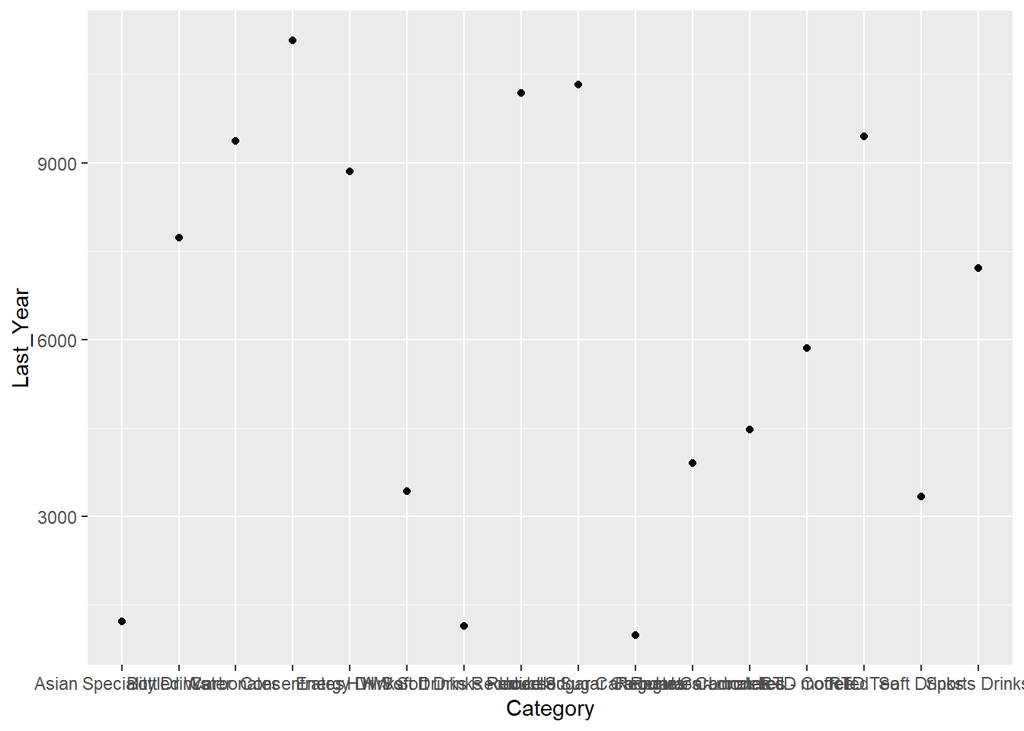

```r
ggplot(market2, aes(y = Last_Year, x = Category)) +
  geom_point()
```

Agregamos leyendas en ambos ejes y ajustamos escala

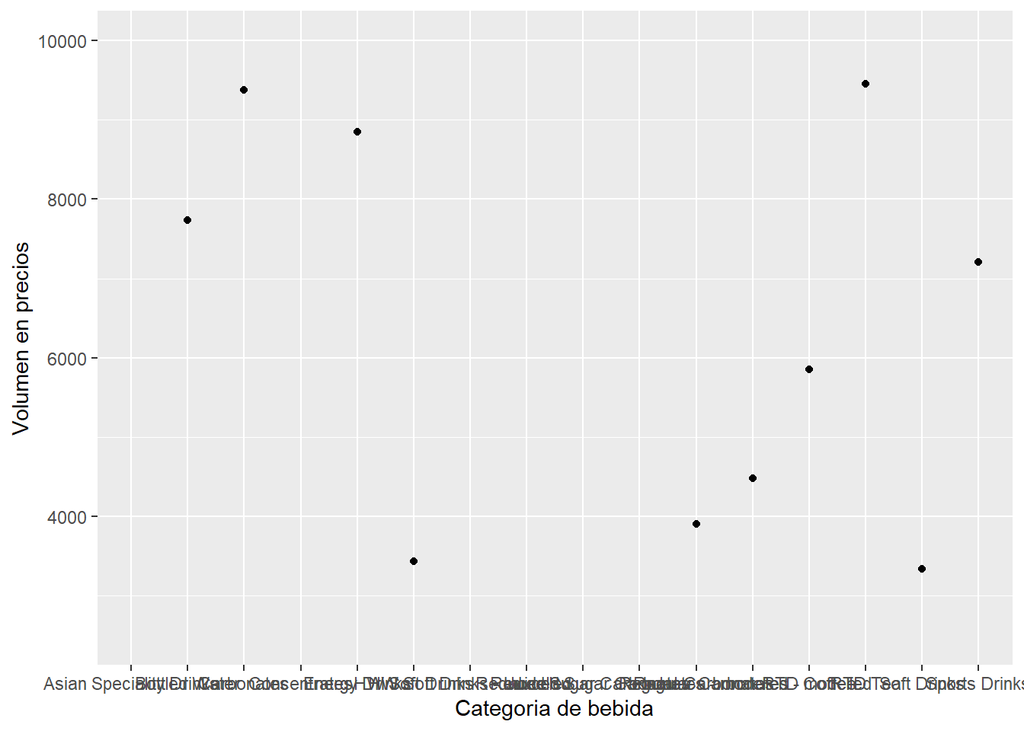

```r
ggplot(market2, aes(y = Last_Year, x = Category)) +
  geom_point() +
  scale_y_continuous(limits = c(2500, 10000))+
  ylab("Volumen en precios")+
  xlab("Categoria de bebida")
```

Un poco mejor…

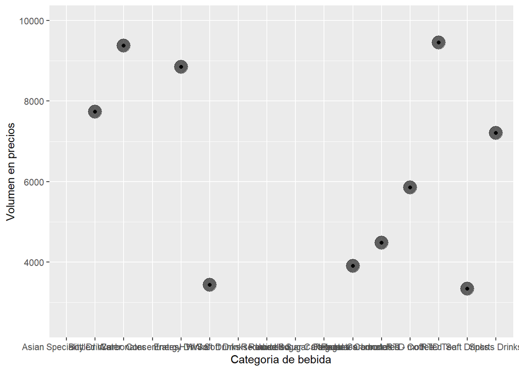

```r
ggplot(market2, aes(y = Last_Year, x = Category)) +
  geom_point() +
  geom_point(size= 6, alpha= .6) +
  scale_y_continuous(limits = c(2500, 10000))+
  ylab("Volumen en precios")+
  xlab("Categoria de bebida")
```

O mejor asi…

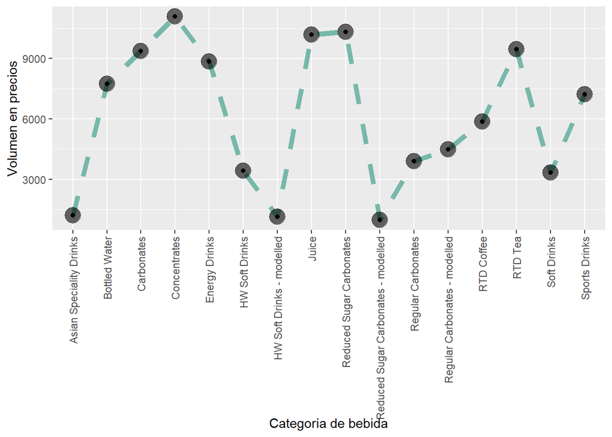

```r
ggplot(market2, aes(y = Last_Year, x = factor(Category))) +
  geom_line(aes(group=1),color="#69b3a2", size=2, alpha=0.9, linetype=2) +
  geom_point() +
  geom_point(size= 6, alpha= .6) +
  #scale_y_continuous(limits = c(2500, 10000))+
  ylab("Volumen en precios")+
  xlab("Categoria de bebida")+
  theme(axis.text.x = element_text(angle = 90, vjust = 0.5, hjust=1))
```

Sin embargo podemos hacer mejores visualizaciones con mejores datos…

Volvemos a ordenar el set original, ojo con la función `gather`.

Para mas información busquen referencias en “tidyr” relacionadas a `gather` y `spread`.

```r
library(tidyr)
market <- read_csv("data/Market_size.csv", skip = 5)
market<- market %>%
  mutate(across(6:12, as.numeric)) %>%
  filter(`Current Constant` == "Current Prices")
market<- gather(market, key = "Año", value = "Prices",
       (6:12))
market
```

```
## # A tibble: 5,992 x 7
##    Geography  Category         `Data Type` Unit  `Current Constant` Año   Prices
##    <chr>      <chr>            <chr>       <chr> <chr>              <chr>  <dbl>
##  1 Azerbaijan HW Soft Drinks ~ Retail Val~ AZN ~ Current Prices     2017   265.
##  2 Azerbaijan Soft Drinks      Off-trade ~ AZN ~ Current Prices     2017   542
##  3 Azerbaijan Bottled Water    Off-trade ~ AZN ~ Current Prices     2017   123
##  4 Azerbaijan Carbonates       Off-trade ~ AZN ~ Current Prices     2017   234.
##  5 Azerbaijan Regular Carbona~ Off-trade ~ AZN ~ Current Prices     2017   226.
##  6 Azerbaijan Reduced Sugar C~ Off-trade ~ AZN ~ Current Prices     2017     7.8
##  7 Azerbaijan Concentrates     Off-trade ~ AZN ~ Current Prices     2017    28
##  8 Azerbaijan Juice            Off-trade ~ AZN ~ Current Prices     2017    24.6
##  9 Azerbaijan RTD Coffee       Off-trade ~ AZN ~ Current Prices     2017     0.7
## 10 Azerbaijan RTD Tea          Off-trade ~ AZN ~ Current Prices     2017    31.1
## # i 5,982 more rows
```

```r
market <- market %>%
  mutate(Año= as.numeric(Año)) %>%
  group_by(Category,Año) %>%
  summarise(Precios = sum(Prices, na.rm=TRUE))
market
```

```
## # A tibble: 112 x 3
## # Groups:   Category [16]
##    Category                  Año Precios
##    <chr>                   <dbl>   <dbl>
##  1 Asian Speciality Drinks  2017   1671
##  2 Asian Speciality Drinks  2018   1757.
##  3 Asian Speciality Drinks  2019   1847.
##  4 Asian Speciality Drinks  2020   1933.
##  5 Asian Speciality Drinks  2021   2005.
##  6 Asian Speciality Drinks  2022   2150
##  7 Asian Speciality Drinks  2023   1224.
##  8 Bottled Water            2017   8444.
##  9 Bottled Water            2018   8354.
## 10 Bottled Water            2019   7818.
## # i 102 more rows
```

y ahora si toma sentido!!

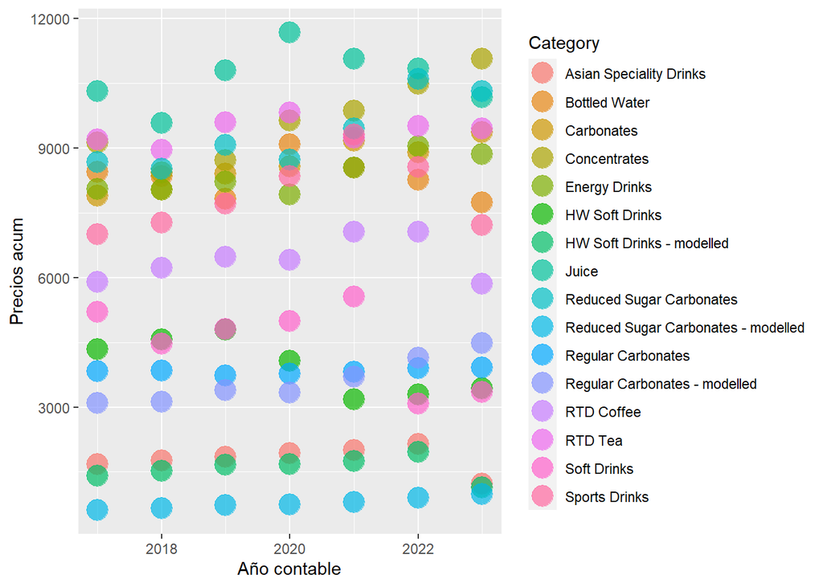

```r
ggplot(market, aes(y = Precios, x = Año, colour = Category)) +
  geom_point(size= 6, alpha= .7) +
  #scale_x_continuous(limits = c(2016.5, 2023.5))+
  ylab("Precios acum")+
  xlab("Año contable")
```

O mejor aun…se puede?

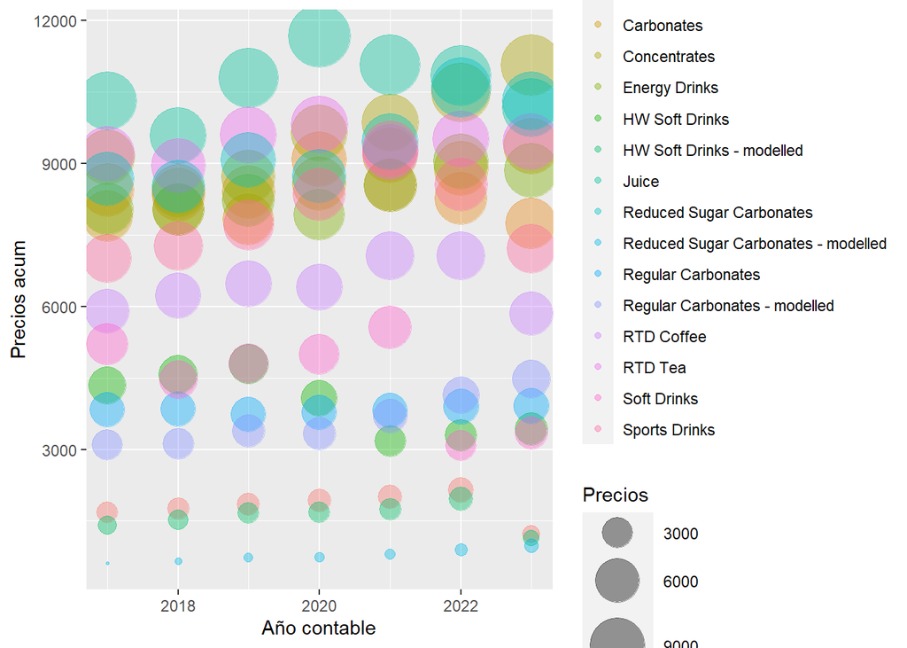

```r
ggplot(market, aes(y = Precios, x = Año, colour = Category)) +
  geom_point(aes(size = Precios), alpha = 0.4)+
  ylab("Precios acum")+
  xlab("Año contable")+
  scale_size(range = c(0.5, 16))  #Ajusta el tamaño de los circulos
```

Reordenamos datos, y permitimos tener la categoria de precios y litros.

```r
market <- read_csv("data/Market_size.csv", skip = 5)
market<- market %>%
  mutate(across(6:12, as.numeric))
market<- gather(market, key = "Año", value = "Prices",
       (6:12))
market <- market %>%
  mutate(Año= as.numeric(Año)) %>%
  group_by(Category,`Current Constant`, Año) %>%
  mutate(`Current Constant` = str_replace(`Current Constant`, "-", "Litros")) %>%
  summarise(Precios_Lts = sum(Prices, na.rm=TRUE))
market <- market %>% spread(`Current Constant`, Precios_Lts)
market
```

```
## # A tibble: 112 x 4
## # Groups:   Category [16]
##    Category                  Año `Current Prices` Litros
##    <chr>                   <dbl>            <dbl>  <dbl>
##  1 Asian Speciality Drinks  2017            1671   1143
##  2 Asian Speciality Drinks  2018            1757.  1214
##  3 Asian Speciality Drinks  2019            1847.  1239.
##  4 Asian Speciality Drinks  2020            1933.  1081.
##  5 Asian Speciality Drinks  2021            2005.  1055.
##  6 Asian Speciality Drinks  2022            2150   1067.
##  7 Asian Speciality Drinks  2023            1224.  1048.
##  8 Bottled Water            2017            8444. 16049.
##  9 Bottled Water            2018            8354. 15956.
## 10 Bottled Water            2019            7818. 16699.
## # i 102 more rows
```

Hacemos algunas graficas ya un poco conocidas…

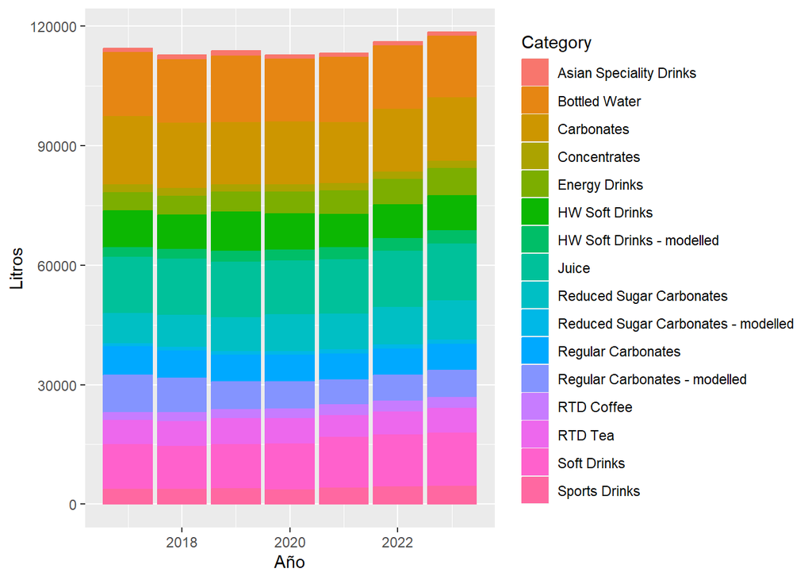

```r
ggplot(market, aes(x = Año, y = Litros)) +
  geom_col(aes(color = Category, fill = Category), position = position_stack())
```

de mis favoritas…

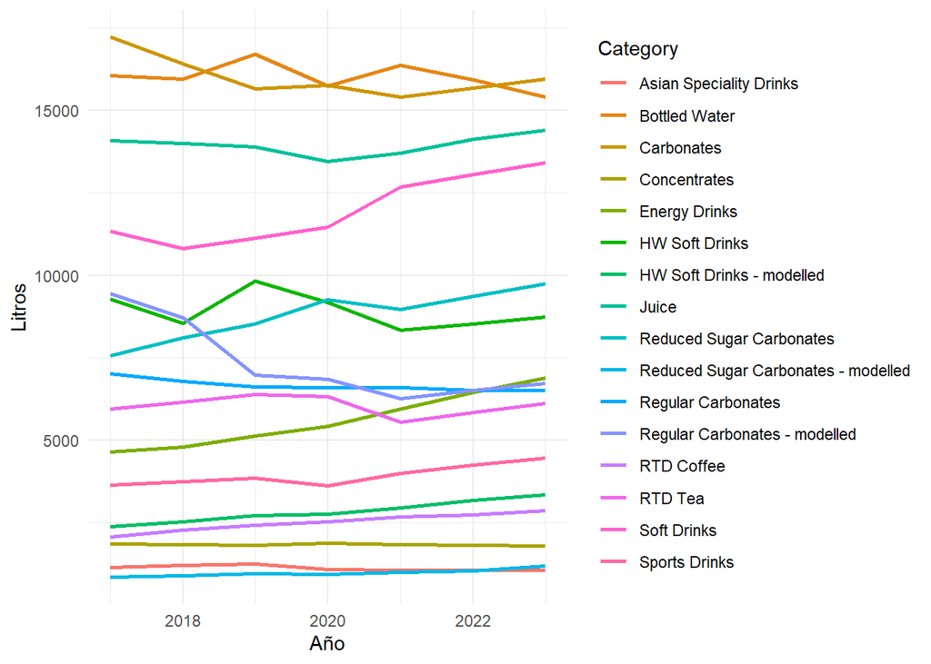

```r
# Multiple line plot
ggplot(market, aes(x = Año, y = Litros)) +
  geom_line(aes(color = Category), size = 1) +
  theme_minimal()
```

Le subimos el volumen!!! Su primera regresión…

Nos detendremos un poco a comentar….

**Regresión**

Es un modelo matemático usado para aproximar la relación de dependencia entre una variable dependiente $Y$, las variables independientes $Xi$ y un término aleatorio. La regresion tiene como objetivo predecir observaciones futuras.

La ecuación general se puede representar de la siguiente forma:

$Y=β0+∑ βiXi+ϵi$

donde $β$ representa las estimaciones de parámetros lineales que se deben calcular y $ϵ$ representa los términos de error.

Existen diferentes tipos de regresiones lineales como son:

- Regresión lineal simple: modelos que utilizan un único predictor. La ecuación general es:

$Y=β0+βiX+ϵi$

- Regresión lineal múltiple: modelos que utilizan múltiples predictores. Esta regresión tiene múltiples $Xi$ para predecir la respuesta, $Y$ . Este es un ejemplo de la ecuación:

$Y=β0+β1X1+β2X2+ϵ$

- Regresión lineal multivariante: modelos para varias variables de respuesta. Esta regresión tiene múltiples $Yi$ que derivan de los mismos datos $Y$. Se expresan con fórmulas diferentes. Este es un ejemplo del sistema con 2 ecuaciones:

$Y1=β01+β11X1+ϵ1$

$Y2=β02+β12X1+ϵ2$

Regresión lineal múltiple multivariante: modelos que utilizan varios predictores para múltiples variables de respuesta. Esta regresión tiene múltiples $Xi$ para predecir varias respuestas $Yi$.

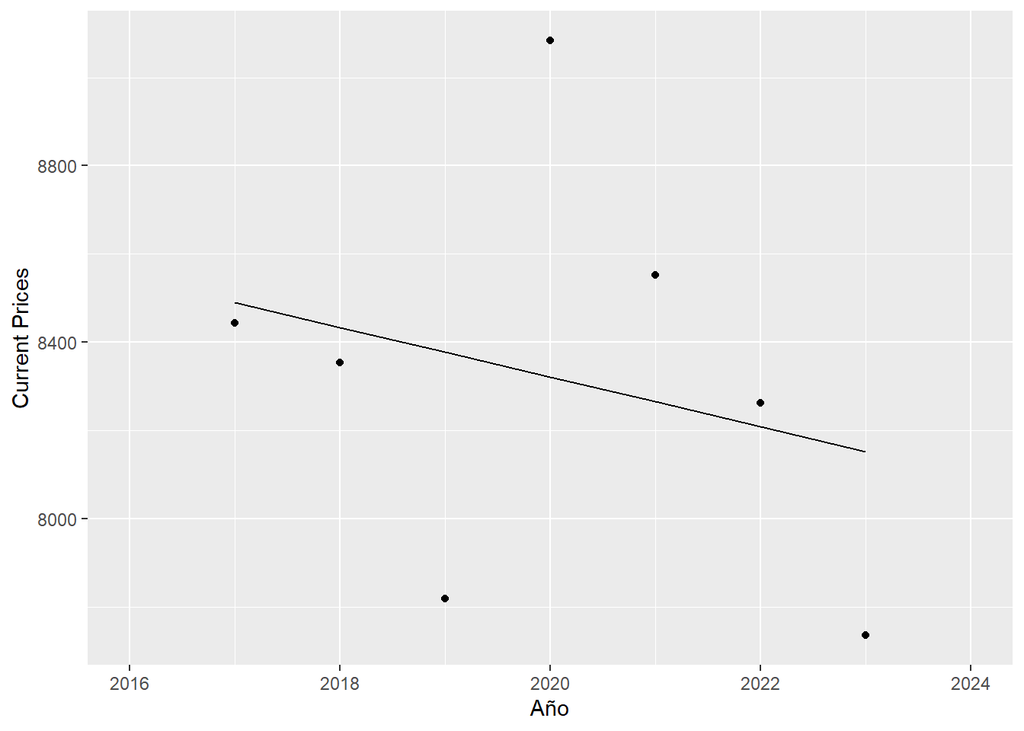

```r
#Obtenemos los datos de aguas embotelladas para predicir el dato del 2024
agua_e <- market %>%
  filter(Category == "Bottled Water") %>%
  group_by(Category, Año)
#Una regresion lineal sencilla
#Obtenemos los coeficientes
regresion <- lm(`Current Prices`~Año, data = agua_e)
#Ajustamos
agua_e$prediccion <- predict(regresion)

#De mejor interpretación
p1 <- ggplot(agua_e, aes(x = Año, y = `Current Prices`))

p1 + geom_point() +
  scale_x_continuous(limits = c(2016, 2024)) +
  geom_line(aes(y = prediccion))
```

Agregamos unas bandas de confianza representadas por una sombra, y pintamos nuestros datos en “azul”…

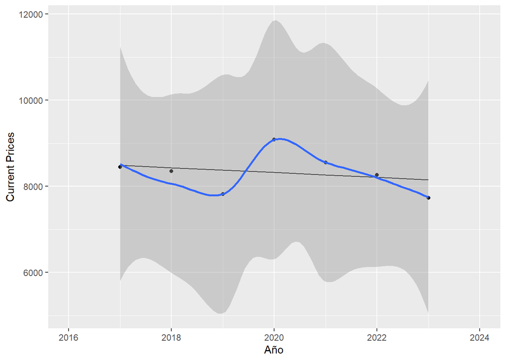

```r
p1 + geom_point() +
  scale_x_continuous(limits = c(2016, 2024)) +
  geom_line(aes(y = prediccion)) +
  geom_smooth()
```

…pero y el año 2024 y el 2025 como va a cerrar? en donde esta la predicción/estimación?

Ideas??

Seguimos con la magia!!!

```r
conf1 <- predict(regresion,interval="confidence")
pred1 <- predict(regresion,interval="prediction")
```

Pasamos los siguientes dos años… (づ｡◕‿‿◕｡)づ

```r
new <- data.frame(Año=seq(2024,2025,length=2))
conf2 <- predict(regresion,interval="confidence",newdata=new)
pred2 <- predict(regresion,interval="prediction",newdata=new)
new$prediccion <- predict(regresion,newdata=new)
new
```

```
##    Año prediccion
## 1 2024   8096.514
## 2 2025   8040.296
```

y lo graficamos para que se entienda mejor

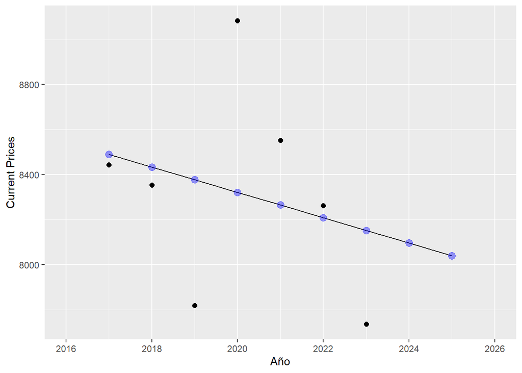

```r
agua_e_pred <-bind_rows(agua_e,new)
p2 <- ggplot(agua_e_pred, aes(x = Año, y = `Current Prices`))
p2 + geom_point(size= 2) +
  scale_x_continuous(limits = c(2016, 2026)) +
  geom_line(aes(y = prediccion)) +
  geom_point(aes(y = prediccion),color= "blue", size= 3, alpha = 0.4)
```

revisamos el detalle que nos da el objeto `lm`, las bandas de confianza y de predicción

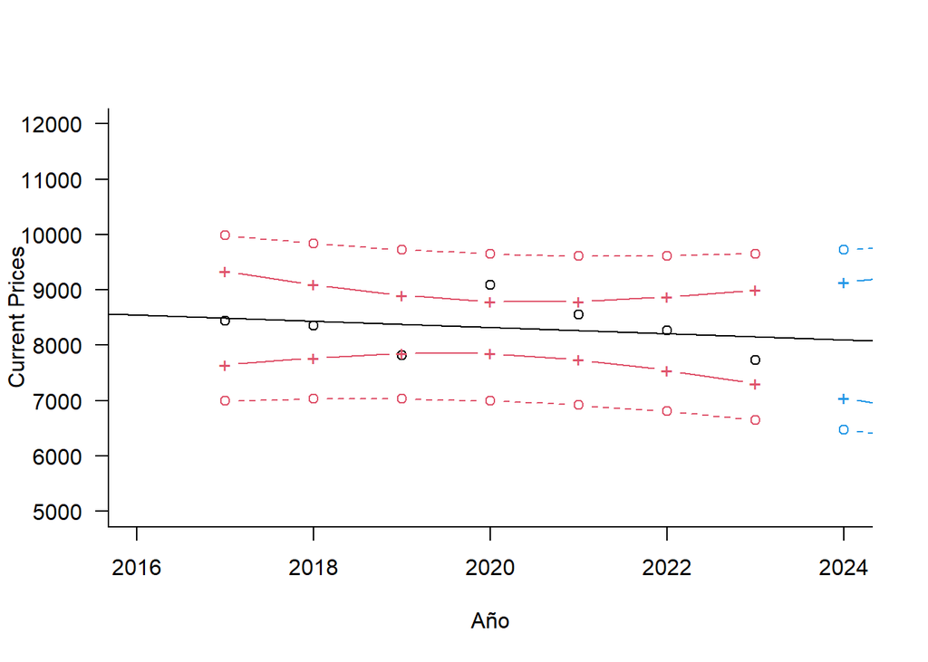

```r
par(las=1,bty="l") ## formato
plot(`Current Prices`~Año,data=agua_e,ylim=c(5000,12000),xlim=c(2016,2024)) ## datos originales
abline(regresion) ## ajuste del modelo
matlines(agua_e$Año,conf1[,c("lwr","upr")],col=2,lty=1,type="b",pch="+")
matlines(agua_e$Año,pred1[,c("lwr","upr")],col=2,lty=2,type="b",pch=1)
matlines(new$Año,conf2[,c("lwr","upr")],col=4,lty=1,type="b",pch="+")
matlines(new$Año,pred2[,c("lwr","upr")],col=4,lty=2,type="b",pch=1)
```

Mas ideas, revisen el siguiente [link.](https://www.datanovia.com/en/blog/ggplot-examples-best-reference/)

Buenisimos tutoriales, muchas gracias a los amigos de datanovia!!!

Ademas pueden revisar el documento de apoyo data-visualization-2.1.pdf que esta en el repo del Workshop.

### Bonus

`OBJETIVO:` **Mostrarles que aún hay mas cosas en el universo de `R` y generar mas ideas para sus proyectos.**

#### A. Strings

```r
a <- 'Empieza y termina con comilla sencilla'
a
```

```
## [1] "Empieza y termina con comilla sencilla"
```

```r
b <- "Empieza y termina con comillas"
b
```

```
## [1] "Empieza y termina con comillas"
```

```r
c <- "Comilla sencilla ' en medio de comillas"
c
```

```
## [1] "Comilla sencilla ' en medio de comillas"
```

```r
d <- 'Comillas " en medio de comilla sencilla al inicio y al final'
d
```

```
## [1] "Comillas \" en medio de comilla sencilla al inicio y al final"
```

Ejemplo de *strings* invalidos:

```r
e <- 'Comillas mezcladas"
Resultado:
INCOMPLETE_STRING
```

```r
f <- 'Una comilla sencilla ' dentro de otras comillas sencillas'
Resultado:
INCOMPLETE_STRING
```

```r
g <- "Comillas " dentro de comillas dobles"
Resultado:
INCOMPLETE_STRING
```

Para concatenar strings usamos algo muy sencillo `paste`

```r
a <- "D00"
b <- '1234'
c <- "2019 1"

print(paste(a,b,c))
```

```
## [1] "D00 1234 2019 1"
```

```r
print(paste(a,b,c, sep = "-"))
```

```
## [1] "D00-1234-2019 1"
```

```r
print(paste(a,b,c, sep = "", collapse = ""))
```

```
## [1] "D0012342019 1"
```

Para formatear los strings también usamos algo sencillo:

```r
# Justificar a la Izquierda
cadena <- format("Cuota", width = 6, justify = "l")
cadena
```

```
## [1] "Cuota "
```

```r
# Justificar al centro
cadena <- format("Cuota", width = 9, justify = "c")
cadena
```

```
## [1] "  Cuota  "
```

Podemos contar los caracteres de una oración con `nchar()`

```r
cadena2 <- nchar("Prima Emitida en $ usd...")
cadena2
```

```
## [1] 25
```

Podemos cambiar a mayúsculas o minúsculas.

```r
toupper(cadena)
```

```
## [1] "  CUOTA  "
```

```r
tolower(cadena)
```

```
## [1] "  cuota  "
```

Por ultimo podemos hacer substrings más cortos de uno ya existente

```r
# Extraer caracteres de la 5ta a la  7th posición
cadena3 <- substring("Ricardo Lastra", 5, 7)
cadena3
```

```
## [1] "rdo"
```

Adicional a R base pueden revisar la libreria `stringr` cuya sintaxis es muy amigable, esta dentro del universo Tidy que ya conocemos.

Pueden consultar el siguiente link https://cran.r-project.org/web/packages/stringr/vignettes/stringr.html

**REGEX**

Relacionado al tema, tambien revisen un buen tutorial de REGEX ó expresiones regulares, será de gran ayuda!!!

https://tutorialzine.com/2014/12/learn-regular-expressions-in-20-minutes

Herramienta para probar y depurar expresiones regulares.

https://regex101.com/

#### B. Fechas

Son de las cosas que más dolores de cabeza les dan a algunos, sin embargo hay librerías que lo hacen sencillo, las fechas son difíciles de manejar por los formatos en los que cada sistema las almacena, este no depende de los sistemas, sino de la necesidad del usuario, de la zona horaria, y en algunos casos son solo días, meses o horas con minutos y segundos los que se necesitan.

Una magnifica libreria es `lubridate` la cual soporta instantes, intervalos, duraciones y periodos.

```r
fecha <- Sys.Date()
fechas <- seq(fecha, length.out=12, by = "1 month")
fechas
```

```
##  [1] "2023-03-28" "2023-04-28" "2023-05-28" "2023-06-28" "2023-07-28"
##  [6] "2023-08-28" "2023-09-28" "2023-10-28" "2023-11-28" "2023-12-28"
## [11] "2024-01-28" "2024-02-28"
```

más ejemplos…

Accedemos al formato `dd/mm/aaaa` con la funcion **dmy** y obtenemos el mes de la fecha de nacimiento:

```r
library(lubridate)
bday <- dmy("29/05/1986")
month(bday)
```

```
## [1] 5
```

Accedemos al día de la semana de ese año:

```r
wday(bday)
```

```
## [1] 5
```

Y accedemos también al dia del año actual:

```r
year(bday) <- 2019
wday(bday)
```

```
## [1] 4
```

Y en formato `aaaa/mm/dd hr:min:seg` con la funcion **ymd_hms** y obtenemos el mes de la fecha de esta forma:

```r
time <- ymd_hms("2019-06-25 15:30:30")
time
```

```
## [1] "2019-06-25 15:30:30 UTC"
```

Funciones de ayuda para manipular time zones: with_tz(), force_tz()

```r
# Changes printing
with_tz(time, "America/Chicago")
```

```
## [1] "2019-06-25 10:30:30 CDT"
```

```r
# Changes time
force_tz(time, "America/Chicago")
```

```
## [1] "2019-06-25 15:30:30 CDT"
```

#### C. Factores

Cuando uno quiere analizar datos, regularmente necesita variables que funcionan como etiquetas. Estas etiquetas pueden ser contadas, pero no sumadas. A este tipo de variables se les conoce como variables categóricas y en R se llaman factores.

```r
mascotas <- c("P", "G", "P", "P", "G", "P")
mascotas <- factor(mascotas)
mascotas
```

```
## [1] P G P P G P
## Levels: G P
```

```r
mascotas <- factor(c("P", "G", "P", "P", "G", "P","G"), levels=c("G", "P"), labels=c("GATO", "PERRO"))
mascotas
```

```
## [1] PERRO GATO  PERRO PERRO GATO  PERRO GATO
## Levels: GATO PERRO
```

#### D. Paleta de colores

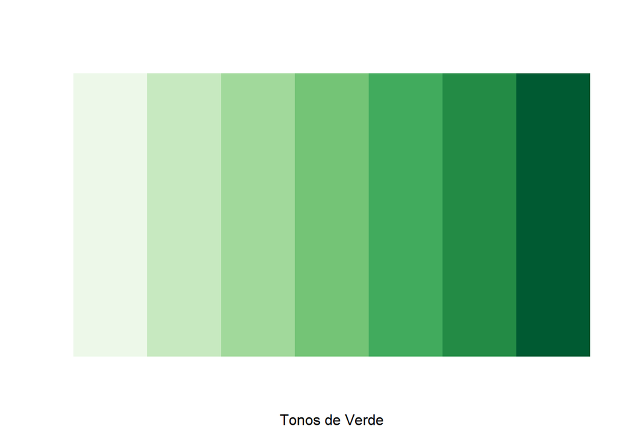

```r
#install.packages("RcolorBrewer")
library(RColorBrewer)
#create a sequential palette for usage and show colors
mypalette<-brewer.pal(7,"Greens")
image(1:7,1,as.matrix(1:7),col=mypalette,xlab="Tonos de Verde",
       ylab="",xaxt="n",yaxt="n",bty="n")
```

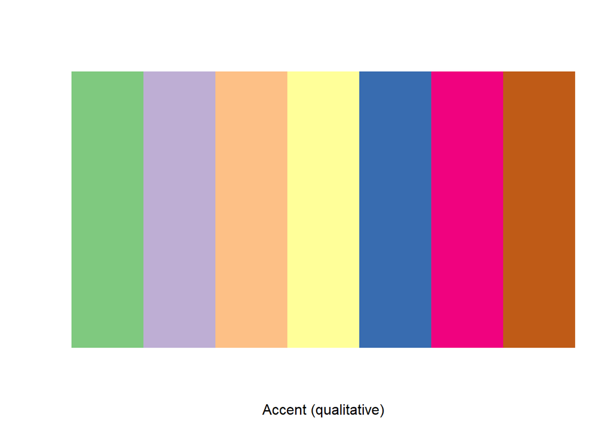

```r
## display a qualitative palette
display.brewer.pal(7,"Accent")
```

Mas información en: https://www.rdocumentation.org/packages/RColorBrewer/versions/1.1-2/topics/RColorBrewer

#### E. Listas

Algo muy util en programación orientada a objetos son las listas, son parecidas a los vectores, pero con una diferencia importante: pueden tener los elementos de diferentes tipos.

```r
lista <- list(1, 2, 3, 4, 5)
lista
```

```
## [[1]]
## [1] 1
##
## [[2]]
## [1] 2
##
## [[3]]
## [1] 3
##
## [[4]]
## [1] 4
##
## [[5]]
## [1] 5
```

El operador de extracción ([), devuelve una lista

```r
lista[1]
```

```
## [[1]]
## [1] 1
```

```r
is.list(lista[1])
```

```
## [1] TRUE
```

```r
is.vector(lista[1])
```

```
## [1] TRUE
```

El operador [[ devuelve un vector

```r
lista[[1]]
```

```
## [1] 1
```

```r
is.list(lista[[1]])
```

```
## [1] FALSE
```

```r
is.vector(lista[[1]])
```

```
## [1] TRUE
```

```r
renta <- list(direccion="Masarik 306", m2=c(10, 15, 3), dlls.men=2500)
renta
```

```
## $direccion
## [1] "Masarik 306"
##
## $m2
## [1] 10 15  3
##
## $dlls.men
## [1] 2500
```

Existe otro operador de acceso: $ (lo vimos en sesiones pasadas también)

```r
renta$dlls.men
```

```
## [1] 2500
```

```r
renta[3]
```

```
## $dlls.men
## [1] 2500
```

```r
renta[[2]]
```

```
## [1] 10 15  3
```

#### F. Mapas interactivos.

Para crear visualizaciones muy buenas a través de mapas, existe `leaflet`, la cual es una librería creada por los amigos de *Rstudio* para integrarla a la distribución del mismo nombre creada en JavaScript.

Es súper interesante este tema, ya que podemos generar mapas interactivos, integrarlos en una APP, publicarlos en línea o hasta ponerlos en nuestro reporte RMD.

Esencialmente el paquete te permite generar mapas con configuraciones personales de map tiles, markers, polygons, lines, popups, y objetos geojson. Casi todo lo que conocemos de Google Fusion Tables o Carto(DB) en esta parte de mapas, ustedes lo pueden hacer usando R y el paquete de `leaflet`.

Aquí un buen ejemplo!!!

```r
#install.packages("leaflet")
library(leaflet)
# Initialize and assign m as the leaflet object
m <- leaflet() %>%
# Now add tiles to it
    addTiles() %>%
# Setting the middle of where the map should be and the zoom level
    setView(lng=-99.2609819, lat=19.3592552, zoom = 16) %>%
# Now, add a marker with a popup,
    addMarkers(lng=-99.2609819, lat=19.3592552, popup="<b>Hola Workshop</b><br><a href='https://www.washingtonpost.com'>-Link_a_sitio_relacionado_con_ubicación</a>")

m
```

[interactive chart not shown]

En donde esta el marcador?? jejeje ⊂(◉‿◉)つ

Un ultimo regalo!!!

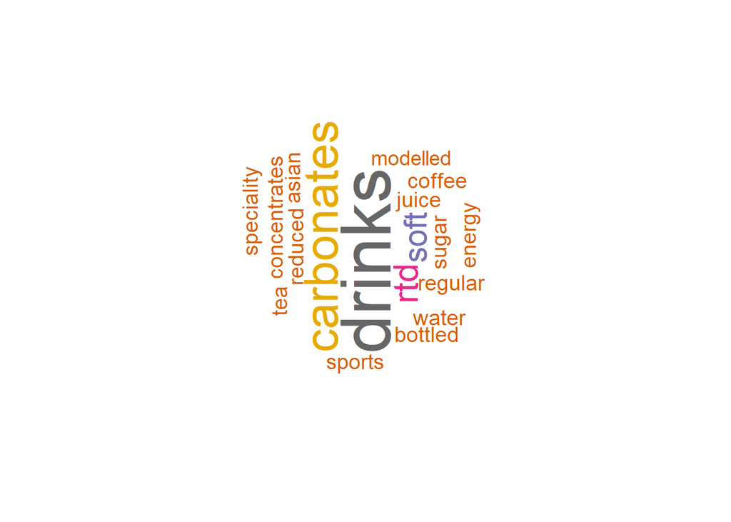

```r
#install.packages("wordcloud")
library(wordcloud)
#install.packages("RColorBrewer")
library(RColorBrewer)
#install.packages("wordcloud2")
library(wordcloud2)
#install.packages("tm")
library(tm)
#Create a vector containing only the text
market <- read_csv("data/Market_size.csv", skip = 5)
text <- market$Category
# Create a corpus
docs <- Corpus(VectorSource(text))
# Have a dataframe containing each word in your first column and their #frequency in the second column
dtm <- TermDocumentMatrix(docs)
matrix <- as.matrix(dtm)
words <- sort(rowSums(matrix),decreasing=TRUE)
df <- data.frame(word = names(words),freq=words)
# Generate the wordcloud
set.seed(1234) # for reproducibility
wordcloud(words = df$word, freq = df$freq, min.freq = 1,           max.words=200, random.order=FALSE, rot.per=0.35,            colors=brewer.pal(8, "Dark2"))
```

Aplausos!!!!!!

#### F. Intermedios-Avanzados R

```
i) Shiny
ii) Simulación
iii) Web Scrapping
iv) Algoritmos de ML
v) Algoritmos de Texto
vi) Creando paqueterias
vii) Programación en Paralelo
viii) API´s
```

#### G. Otras herramientas

```
i) Git
ii) Spark & Keras
iii) SQLite, JS, C, C#
iv) Docker
v) Bash programming, paralelo
vi) Computo Cloud / AWS (Amazon cloud services) / AZURE (Microsoft)
```

Muchas gracias!!!